# Exercise 3.9 - Interpreting Priors

Porovnanie Beta priorov pre rôzne regióny USA

Dana Kozáková

2025-10-24

## Úvod

Riešenie cvičenia 3.9 z knihy [Bayes Rules!](https://www.bayesrulesbook.com/chapter-3#exercises-2)

Interpretácia a porovnanie Beta apriórnych modelov pre proporciu obyvateľov USA, ktorí používajú výraz “pop” pre sladené nápoje.

## Exercise 3.9: Interpreting Priors

> What do you call a sweet carbonated drink: pop, soda, coke, or something else? Let $\pi$ be the proportion of U.S. residents that prefer the term “pop.” Two different beverage salespeople from different regions of the country have different priors for $\pi$. The first salesperson works in North Dakota and specifies a Beta(8,2) prior. The second works in Louisiana and specifies a Beta(1,20) prior.
> 1. Calculate the prior mean, mode, standard deviation of $\pi$ for both salespeople.
> 2. Plot the prior pdfs for both salespeople.
> 3. Compare, in words, the salespeople’s prior understandings about the proportion of U.S. residents that say “pop.”

## Zadanie úlohy

### Kontext

**Parameter záujmu:** $\pi$ = proporcia obyvateľov USA, ktorí používajú výraz “pop” pre sladené nápoje

**Dvaja predajcovia z rôznych regiónov:**

1. **Predajca z North Dakota (ND):** má apriórny model $\pi \sim \text{Beta}(8, 2)$
2. **Predajca z Louisiana (LA):** má apriórny model $\pi \sim \text{Beta}(1, 20)$

## Solution

### a. Výpočet charakteristík apriórnych modelov

#### Vzorce pre Beta rozdelenie

Pre $\pi \sim \text{Beta}(\alpha, \beta)$ platí:

$$\begin{align}
E(\pi) &= \frac{\alpha}{\alpha + \beta} \\
\text{Mode}(\pi) &= \frac{\alpha - 1}{\alpha + \beta - 2} \quad
\text{pre } \alpha, \beta > 1 \\
\text{Var}(\pi) &= \frac{\alpha \beta}{(\alpha + \beta)^2(\alpha +
\beta + 1)} \\
\text{SD}(\pi) &= \sqrt{\text{Var}(\pi)}
\end{align}$$

#### Predajca z North Dakota: Beta(8, 2)

```r
# Parametre pre North Dakota
alpha_nd <- 8
beta_nd <- 2

# Výpočet charakteristík
mean_nd <- alpha_nd / (alpha_nd + beta_nd)
mode_nd <- (alpha_nd - 1) / (alpha_nd + beta_nd - 2)
var_nd <- (alpha_nd * beta_nd) / ((alpha_nd + beta_nd)^2 * (alpha_nd + beta_nd + 1))
sd_nd <- sqrt(var_nd)

cat("North Dakota - Beta(8, 2):\n")
```

```
## North Dakota - Beta(8, 2):
```

```r
cat("Stredná hodnota (mean):", round(mean_nd, 4), "\n")
```

```
## Stredná hodnota (mean): 0.8
```

```r
cat("Modus (mode):", round(mode_nd, 4), "\n")
```

```
## Modus (mode): 0.875
```

```r
cat("Rozptyl (variance):", round(var_nd, 4), "\n")
```

```
## Rozptyl (variance): 0.0145
```

```r
cat("Smerodajná odchýlka (SD):", round(sd_nd, 4), "\n")
```

```
## Smerodajná odchýlka (SD): 0.1206
```

**Výpočet pomocou vzorcov:**

$$\begin{align}
E(\pi) &= \frac{8}{8 + 2} = \frac{8}{10} = 0.8 \\
\text{Mode}(\pi) &= \frac{8 - 1}{8 + 2 - 2} = \frac{7}{8} = 0.875 \\
\text{Var}(\pi) &= \frac{8 \times 2}{10^2 \times 11} =
\frac{16}{1100} \approx 0.0145 \\
\text{SD}(\pi) &= \sqrt{0.0145} \approx 0.1205
\end{align}$$

#### Predajca z Louisiana: Beta(1, 20)

```r
# Parametre pre Louisiana
alpha_la <- 1
beta_la <- 20

# Výpočet charakteristík
mean_la <- alpha_la / (alpha_la + beta_la)
# Mode nie je definovaný pre alpha = 1, beta > 1 (klesajúca funkcia)
mode_la <- ifelse(alpha_la > 1 & beta_la > 1,
                  (alpha_la - 1) / (alpha_la + beta_la - 2),
                  NA)
var_la <- (alpha_la * beta_la) / ((alpha_la + beta_la)^2 * (alpha_la + beta_la + 1))
sd_la <- sqrt(var_la)

cat("Louisiana - Beta(1, 20):\n")
```

```
## Louisiana - Beta(1, 20):
```

```r
cat("Stredná hodnota (mean):", round(mean_la, 4), "\n")
```

```
## Stredná hodnota (mean): 0.0476
```

```r
cat("Modus (mode):", ifelse(is.na(mode_la), "neexistuje (klesajúca funkcia)", round(mode_la, 4)), "\n")
```

```
## Modus (mode): neexistuje (klesajúca funkcia)
```

```r
cat("Rozptyl (variance):", round(var_la, 4), "\n")
```

```
## Rozptyl (variance): 0.0021
```

```r
cat("Smerodajná odchýlka (SD):", round(sd_la, 4), "\n")
```

```
## Smerodajná odchýlka (SD): 0.0454
```

**Výpočet pomocou vzorcov:**

$$\begin{align}
E(\pi) &= \frac{1}{1 + 20} = \frac{1}{21} \approx 0.0476 \\
\text{Mode}(\pi) &= \text{neexistuje (pre } \alpha = 1, \beta > 1
\text{ je funkcia klesajúca)} \\
\text{Var}(\pi) &= \frac{1 \times 20}{21^2 \times 22} =
\frac{20}{9702} \approx 0.0021 \\
\text{SD}(\pi) &= \sqrt{0.0021} \approx 0.0453
\end{align}$$

#### Porovnanie charakteristík

```r
comparison <- data.frame(
  Predajca = c("North Dakota", "Louisiana"),
  Prior = c("Beta(8, 2)", "Beta(1, 20)"),
  Mean = c(mean_nd, mean_la),
  Mode = c(mode_nd, 0),
  SD = c(sd_nd, sd_la),
  Variance = c(var_nd, var_la)
)

comparison <- comparison %>%
  mutate(across(c(Mean, Mode, SD, Variance), ~round(.x, 4)))

knitr::kable(comparison, caption = "Porovnanie apriórnych modelov")
```

Porovnanie apriórnych modelov

| Predajca | Prior | Mean | Mode | SD | Variance |
| --- | --- | --- | --- | --- | --- |
| North Dakota | Beta(8, 2) | 0.8000 | 0.875 | 0.1206 | 0.0145 |
| Louisiana | Beta(1, 20) | 0.0476 | 0.000 | 0.0454 | 0.0021 |

### b. Graf apriórnych hustôt pravdepodobnosti (pdf)

#### Porovnanie oboch priorov na jednom grafe

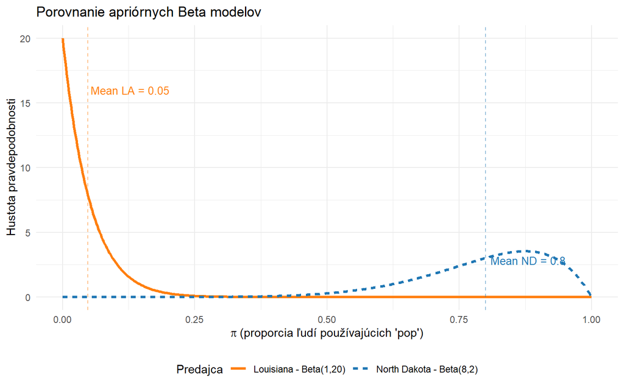

```r
# Vytvorenie dát pre grafy
pi_vals <- seq(0, 1, length.out = 500)

# Husty pre oba priory
density_nd <- dbeta(pi_vals, alpha_nd, beta_nd)
density_la <- dbeta(pi_vals, alpha_la, beta_la)

# Vytvorenie data frame pre ggplot
df_priors <- data.frame(
  pi = rep(pi_vals, 2),
  density = c(density_nd, density_la),
  Region = rep(c("North Dakota - Beta(8,2)", "Louisiana - Beta(1,20)"),
               each = length(pi_vals))
)

# Graf oboch priorov
ggplot(df_priors, aes(x = pi, y = density, color = Region, linetype = Region)) +
  geom_line(size = 1.2) +
  labs(
    title = "Porovnanie apriórnych Beta modelov",
    x = expression(pi ~ "(proporcia ľudí používajúcich 'pop')"),
    y = "Hustota pravdepodobnosti",
    color = "Predajca",
    linetype = "Predajca"
  ) +
  theme_minimal() +
  theme(legend.position = "bottom") +
  scale_color_manual(values = c("North Dakota - Beta(8,2)" = "#1f77b4",
                                  "Louisiana - Beta(1,20)" = "#ff7f0e")) +
  geom_vline(xintercept = mean_nd, color = "#1f77b4", linetype = "dashed", alpha = 0.5) +
  geom_vline(xintercept = mean_la, color = "#ff7f0e", linetype = "dashed", alpha = 0.5) +
  annotate("text", x = mean_nd + 0.08, y = max(density_nd) * 0.8,
           label = paste0("Mean ND = ", round(mean_nd, 2)),
           color = "#1f77b4", size = 3.5) +
  annotate("text", x = mean_la + 0.08, y = max(density_la) * 0.8,
           label = paste0("Mean LA = ", round(mean_la, 2)),
           color = "#ff7f0e", size = 3.5)
```

#### Samostatný graf pre North Dakota

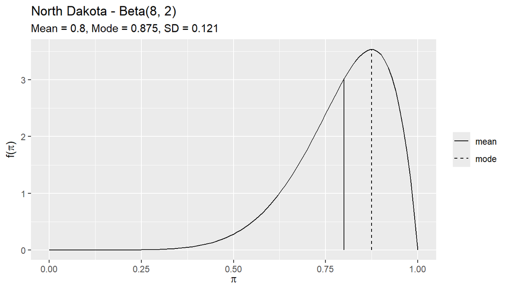

```r
plot_beta(alpha = alpha_nd, beta = beta_nd, mean = TRUE, mode = TRUE) +
  labs(title = "North Dakota - Beta(8, 2)",
       subtitle = paste0("Mean = ", round(mean_nd, 3), ", Mode = ", round(mode_nd, 3),
                        ", SD = ", round(sd_nd, 3)))
```

#### Samostatný graf pre Louisiana

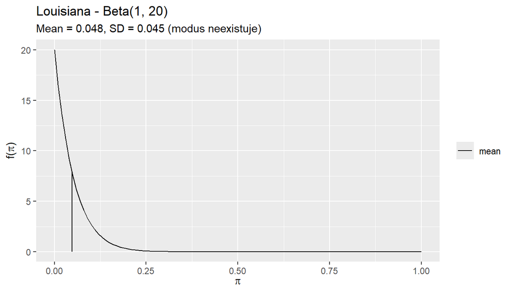

```r
plot_beta(alpha = alpha_la, beta = beta_la, mean = TRUE, mode = FALSE) +
  labs(title = "Louisiana - Beta(1, 20)",
       subtitle = paste0("Mean = ", round(mean_la, 3), ", SD = ", round(sd_la, 3),
                        " (modus neexistuje)"))
```

### c. Porovnanie a interpretácia apriórnych modelov

#### 1. Poloha (centrálna tendencia)

**North Dakota - Beta(8, 2):**

- Stredná hodnota: $E(\pi) = 0.80$ (80%)
- Modus: $\text{Mode}(\pi) = 0.875$ (87.5%)
- Predajca z North Dakota **silno verí**, že väčšina (približne 80%) obyvateľov USA používa výraz “pop”

**Louisiana - Beta(1, 20):**

- Stredná hodnota: $E(\pi) = 0.048$ (4.8%)
- Distribúcia je klesajúca (maximum pri $\pi = 0$)
- Predajca z Louisiana **silno verí**, že len veľmi malá časť (približne 5%) obyvateľov USA používa výraz “pop”

**Záver o polohe:** Oba predajcovia majú **diametrálne odlišné** presvedčenia! North Dakota verí, že “pop” je veľmi populárne, zatiaľ čo Louisiana verí opak.

#### 2. Variabilita (neistota)

**North Dakota - Beta(8, 2):**

- Smerodajná odchýlka: $\text{SD}(\pi) = 0.121$ (12.1%)
- Celkový počet “pozorovaní”: $\alpha + \beta = 10$
- Stredná až vysoká neistota

**Louisiana - Beta(1, 20):**

- Smerodajná odchýlka: $\text{SD}(\pi) = 0.045$ (4.5%)
- Celkový počet “pozorovaní”: $\alpha + \beta = 21$
- Nižšia neistota (viac “istý” vo svojom presvedčení)

**Záver o variabilite:** Predajca z Louisiana je **istejší** vo svojom presvedčení (menšia SD), aj keď má iný názor. North Dakota má vyššiu neistotu.

#### 3. Tvar distribúcie

**North Dakota - Beta(8, 2):**

- $\alpha > \beta$ → distribúcia je **zošikmená doľava** (left-skewed)
- Väčšina pravdepodobnostnej masy je pri **vysokých hodnotách** $\pi$
- Maximum pri $\pi \approx 0.875$

**Louisiana - Beta(1, 20):**

- $\alpha < \beta$ a $\alpha = 1$ → distribúcia je **silno zošikmená doprava** (right-skewed)
- Väčšina pravdepodobnostnej masy je pri **nízkych hodnotách** $\pi$
- Funkcia klesá od $\pi = 0$ smerom doprava

#### 4. Regionálny kontext

**Prečo takéto rozdiely?**

Tieto apriórne modely odrážajú **regionálne rozdiely v USA**:

- **North Dakota** (Stredný západ/Sever USA): V tejto oblasti je výraz “pop” skutočne veľmi bežný
- **Louisiana** (Juh USA): V južných štátoch sa typicky používa “coke” alebo “soda”, nie “pop”

Každý predajca má apriórny model založený na **svojej lokálnej skúsenosti**, ale úloha je o proporcii v **celých USA**, nie len v ich regióne!

## Zhrnutie

### Kľúčové rozdiely

| Charakteristika | North Dakota Beta(8,2) | Louisiana Beta(1,20) |
| --- | --- | --- |
| Stredná hodnota | 0.80 (80%) | 0.048 (4.8%) |
| Modus | 0.875 (87.5%) | neexistuje (klesá) |
| Smer. odchýlka | 0.121 (12.1%) | 0.045 (4.5%) |
| Presvedčenie | “pop” je populárne | “pop” je zriedkavé |
| Neistota | stredná | nízka |
| Tvar | zošikmené doľava | zošikmené doprava |

### Interpretácia

1. **Diametrálne rozdielne presvedčenia:** Jeden predajca verí, že takmer všetci hovoria “pop”, druhý verí, že takmer nikto
2. **Regionálne skúsenosti:** Oba priory odrážajú lokálne skúsenosti predajcov, nie celonárodnú realitu
3. **Rôzna istota:** Louisiana je istejší (menšia SD), North Dakota má väčšiu variabilitu
4. **Dôležitosť dát:** S takto odlišnými priormi bude zaujímavé vidieť, ako sa posteriorné modely zmenia po pozorovaní skutočných celonárodných dát!

## Poznámky k Beta rozdeleniu

### Interpretácia parametrov $\alpha$ a $\beta$

Beta($\alpha, \beta$) môžeme interpretovať ako:

- $\alpha - 1$ = počet “úspechov” (ľudia, ktorí hovoria “pop”)
- $\beta - 1$ = počet “neúspechov” (ľudia, ktorí nehovoria “pop”)
- $\alpha + \beta$ = celková “sila” prioru (ekvivalentný počet pozorovaní)

**North Dakota Beta(8, 2):**

- Ako keby videl 7 úspechov a 1 neúspech
- Celková sila: 10 pozorovaní

**Louisiana Beta(1, 20):**

- Ako keby videl 0 úspechov a 19 neúspechov
- Celková sila: 21 pozorovaní
- Je istejší (viac “pozorovaní”)

### Vizualizácia s R funkciou

```r
# Použitie funkcie z bayesrules balíka
cat("=== North Dakota ===\n")
```

```
## === North Dakota ===
```

```r
summarize_beta(alpha = alpha_nd, beta = beta_nd)
```

```
##   mean  mode        var        sd
## 1  0.8 0.875 0.01454545 0.1206045
```

```r
cat("\n=== Louisiana ===\n")
```

```
##
## === Louisiana ===
```

```r
summarize_beta(alpha = alpha_la, beta = beta_la)
```

```
##         mean mode         var         sd
## 1 0.04761905    0 0.002061431 0.04540298
```

## Záver

Cvičenie demonštruje, ako môžu rôzni ľudia (v tomto prípade z rôznych regiónov) mať **úplne odlišné apriórne presvedčenia** o tom istom parametri $\pi$.

Kľúčové ponaučenia:

- Prior odráža naše počiatočné presvedčenie pred videním dát
- Prior môže byť ovplyvnený našimi lokálnymi skúsenosťami
- Beta rozdelenie je flexibilné a môže zachytiť veľmi rôzne typy presvedčení
- V Bayesovskej analýze začneme s priorom a aktualizujeme ho dátami na posterior